# Insight al consumo de alcohol en estudiantes.

Con nuestro proyecto buscamos entender algunas relaciones entre variables que pueden determinar cuales son las posibilidades de tener un alto grado de consumo de alcohol, esto lo hacemos a partid de un dataset de 1044 items con 29 variables, las cuales en su mayoria son categoricas:

**school** - student’s school (binary: ‘GP’ - Gabriel Pereira or ‘MS’ - Mousinho da Silveira)  
**sex** - student’s sex (binary: ‘F’ - female or ‘M’ - male)  
**age** - student’s age (numeric: from 15 to 22)  
**address** - student’s home address type (binary: ‘U’ - urban or ‘R’ - rural)  
**famsize** - family size (binary: ‘LE3’ - less or equal to 3 or ‘GT3’ - greater than 3)  
**Pstatus** - parent’s cohabitation status (binary: ‘T’ - living together or ‘A’ - apart)  
**Medu** - mother’s education (numeric: 0 - none, 1 - primary education (4th grade), 2 ??? 5th to 9th grade, 3 ??? secondary education or 4 ??? higher education)  
**Fedu** - father’s education (numeric: 0 - none, 1 - primary education (4th grade), 2 ??? 5th to 9th grade, 3 ??? secondary education or 4 ??? higher education)  
**Mjob** - mother’s job (nominal: ‘teacher’, ‘health’ care related, civil ‘services’ (e.g. administrative or police), ‘at_home’ or ‘other’)  
**Fjob** - father’s job (nominal: ‘teacher’, ‘health’ care related, civil ‘services’ (e.g. administrative or police), ‘at_home’ or ‘other’)  
**reason** - reason to choose this school (nominal: close to ‘home’, school ‘reputation’, ‘course’ preference or ‘other’)  
**guardian** - student’s guardian (nominal: ‘mother’, ‘father’ or ‘other’)  
**traveltime** - home to school travel time (numeric: 1 - <15 min., 2 - 15 to 30 min., 3 - 30 min. to 1 hour, or 4 - >1 hour)  
**studytime** - weekly study time (numeric: 1 - <2 hours, 2 - 2 to 5 hours, 3 - 5 to 10 hours, or 4 - >10 hours)  
**failures** - number of past class failures (numeric: n if 1<=n<3, else 4)  
**schoolsup** - extra educational support (binary: yes or no)  
**famsup** - family educational support (binary: yes or no)  
**paid** - extra paid classes within the course subject (Math or Portuguese) (binary: yes or no)  
**activities** - extra-curricular activities (binary: yes or no)  
**nursery** - attended nursery school (binary: yes or no)  
**higher** - wants to take higher education (binary: yes or no)  
**internet** - Internet access at home (binary: yes or no)  
**romantic** - with a romantic relationship (binary: yes or no)  
**famrel** - quality of family relationships (numeric: from 1 - very bad to 5 - excellent)  
**freetime** - free time after school (numeric: from 1 - very low to 5 - very high)  
**goout** - going out with friends (numeric: from 1 - very low to 5 - very high)  
**Dalc** - workday alcohol consumption (numeric: from 1 - very low to 5 - very high)  
**Walc** - weekend alcohol consumption (numeric: from 1 - very low to 5 - very high)  
**health** - current health status (numeric: from 1 - very bad to 5 - very good)  
**absences** - number of school absences (numeric: from 0 to 93)

## Proceso para obtener el dataset de prueba y entrenamiento

Como nuestro dataset esta dividido en dos archivos dependiendo de la institucion en la que se realizo la encuesta debemos unirlos en n solo dataset.

```r
d1<-read.table("student-mat.csv",sep=",",header=TRUE)
d2<-read.table("student-por.csv",sep=",",header=TRUE)

d3 <- rbind(d1, d2)
```

Segun el archivo de Kaggle, 382 estudiantes se repiten en los dos datasets. En tanto debemos detectarlos y solo dejar una instancia. El archivo de la plataforma nos provees las columnas que nos permitir?n hacer una clara identificaci?n a falta de un ID por estudiante

```r
columnas.identificadoras <- c("school","sex","age","address","famsize","Pstatus","Medu","Fedu","Mjob","Fjob","reason","nursery","internet")
```

```r
filas.unicas <- rownames(unique(d3[,as.character(columnas.identificadoras)]))
```

Ahora, creamos una variable que contiene estas las filas que no est?n repetidas. adem?s, excluiremos las columnas G1,G2 y G3 ya que no se pueden considerar como causas sino efectos de los dem?s clasificadores, despues hacemos un sumary y un srt del dataset d para verificar sus variables

```r
d <-d3[filas.unicas, 1:30]
d$ID <- seq.int(nrow(d))
summary(d)
```

```
##  school   sex          age        address famsize   Pstatus
##  GP:434   F:390   Min.   :15.00   R:201   GT3:461   A: 83
##  MS:228   M:272   1st Qu.:16.00   U:461   LE3:201   T:579
##                   Median :17.00
##                   Mean   :16.81
##                   3rd Qu.:18.00
##                   Max.   :22.00
##       Medu            Fedu             Mjob           Fjob
##  Min.   :0.000   Min.   :0.000   at_home :141   at_home : 46
##  1st Qu.:2.000   1st Qu.:1.000   health  : 48   health  : 24
##  Median :2.000   Median :2.000   other   :259   other   :373
##  Mean   :2.492   Mean   :2.293   services:144   services:184
##  3rd Qu.:4.000   3rd Qu.:3.000   teacher : 70   teacher : 35
##  Max.   :4.000   Max.   :4.000
##         reason      guardian     traveltime      studytime
##  course    :288   father:152   Min.   :1.000   Min.   :1.000
##  home      :151   mother:453   1st Qu.:1.000   1st Qu.:1.000
##  other     : 74   other : 57   Median :1.000   Median :2.000
##  reputation:149                Mean   :1.565   Mean   :1.927
##                                3rd Qu.:2.000   3rd Qu.:2.000
##                                Max.   :4.000   Max.   :4.000
##     failures      schoolsup famsup     paid     activities nursery
##  Min.   :0.0000   no :592   no :262   no :469   no :343    no :137
##  1st Qu.:0.0000   yes: 70   yes:400   yes:193   yes:319    yes:525
##  Median :0.0000
##  Mean   :0.3323
##  3rd Qu.:0.0000
##  Max.   :3.0000
##  higher    internet  romantic      famrel         freetime
##  no : 71   no :158   no :414   Min.   :1.000   Min.   :1.000
##  yes:591   yes:504   yes:248   1st Qu.:4.000   1st Qu.:3.000
##                                Median :4.000   Median :3.000
##                                Mean   :3.938   Mean   :3.184
##                                3rd Qu.:5.000   3rd Qu.:4.000
##                                Max.   :5.000   Max.   :5.000
##      goout            Dalc            Walc           health
##  Min.   :1.000   Min.   :1.000   Min.   :1.000   Min.   :1.000
##  1st Qu.:2.000   1st Qu.:1.000   1st Qu.:1.000   1st Qu.:2.000
##  Median :3.000   Median :1.000   Median :2.000   Median :4.000
##  Mean   :3.172   Mean   :1.505   Mean   :2.282   Mean   :3.532
##  3rd Qu.:4.000   3rd Qu.:2.000   3rd Qu.:3.000   3rd Qu.:5.000
##  Max.   :5.000   Max.   :5.000   Max.   :5.000   Max.   :5.000
##     absences            ID
##  Min.   : 0.000   Min.   :  1.0
##  1st Qu.: 0.000   1st Qu.:166.2
##  Median : 3.000   Median :331.5
##  Mean   : 4.931   Mean   :331.5
##  3rd Qu.: 8.000   3rd Qu.:496.8
##  Max.   :75.000   Max.   :662.0
```

```r
str(d)
```

```
## 'data.frame':    662 obs. of  31 variables:
##  $ school    : Factor w/ 2 levels "GP","MS": 1 1 1 1 1 1 1 1 1 1 ...
##  $ sex       : Factor w/ 2 levels "F","M": 1 1 1 1 1 2 2 1 2 2 ...
##  $ age       : int  18 17 15 15 16 16 16 17 15 15 ...
##  $ address   : Factor w/ 2 levels "R","U": 2 2 2 2 2 2 2 2 2 2 ...
##  $ famsize   : Factor w/ 2 levels "GT3","LE3": 1 1 2 1 1 2 2 1 2 1 ...
##  $ Pstatus   : Factor w/ 2 levels "A","T": 1 2 2 2 2 2 2 1 1 2 ...
##  $ Medu      : int  4 1 1 4 3 4 2 4 3 3 ...
##  $ Fedu      : int  4 1 1 2 3 3 2 4 2 4 ...
##  $ Mjob      : Factor w/ 5 levels "at_home","health",..: 1 1 1 2 3 4 3 3 4 3 ...
##  $ Fjob      : Factor w/ 5 levels "at_home","health",..: 5 3 3 4 3 3 3 5 3 3 ...
##  $ reason    : Factor w/ 4 levels "course","home",..: 1 1 3 2 2 4 2 2 2 2 ...
##  $ guardian  : Factor w/ 3 levels "father","mother",..: 2 1 2 2 1 2 2 2 2 2 ...
##  $ traveltime: int  2 1 1 1 1 1 1 2 1 1 ...
##  $ studytime : int  2 2 2 3 2 2 2 2 2 2 ...
```

[output cut: 17 more lines]

Ahora bien, nuestras variables objetivo ser?n Dalc y Wacl. Estas, nos permiten determinar el nivel de consumo de alcohol en d?a de semana (Dalc) y en fines de semana (Walc) en una escala del 1 al 5. Sin embargo, para prop?sitos de lograr resultados satisfactorios con algunos algoritmos como el arbol de decisi?n se ha convertido en una variable binaria.

Dentro del dataset d, se crear? una columna llamada DalcBina y otra WalcBina donde se guardar? el valor binario determinado por un condicional que evalua si el valor es mayor o menor que 3. En caso de ser mayor a 3 se guardar? un valor de “yes”, de lo contrario “no”

```r
d$DalcBina <- ifelse(d$Dalc>3, "yes", "no")
d$WalcBina <- ifelse(d$Walc>3, "yes", "no")
```

Tambi?n, se usar? una ecuaci?n que nos permite encontrar cu?l ser?a el consumo de alcohol en la totalidad que dar?a sumar Walc y Dalc. Se le denomina Alc y consiste en multiplicar los d?as que comprender?a Walc y Dalc de la semana sobre el total de estos. Determinando as? un valor que es un espectro m?s amplio de ?mbos. Se utiliza la funci?n round() con par?metro digits=0 para obtener numeros redondeados del 1-5 de nuevo.

```r
d$Alc <- round((d$Walc*2+d$Dalc*5)/7,digits = 0)
```

```r
set.seed(400) #Seteo seed para poder repetir el proceso
smp_size <- floor(0.75 * nrow(d))
train_ind <- sample(seq_len(nrow(d)), size = smp_size)
train <- d[train_ind, ]
test <- d[-train_ind, ]
test$Alc <- NULL
```

### age vs Walc by sex

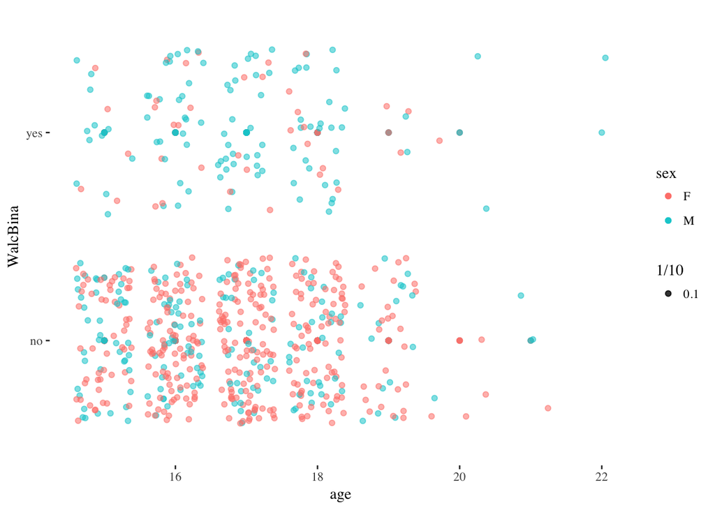

```r
ggplot(d, aes(x=age, y=WalcBina, color=sex, alpha = 1/10)) +
  geom_point() +
  scale_colour_hue(l=70) +
  geom_jitter()
```

### histogram with family relations on x axis with MEAN

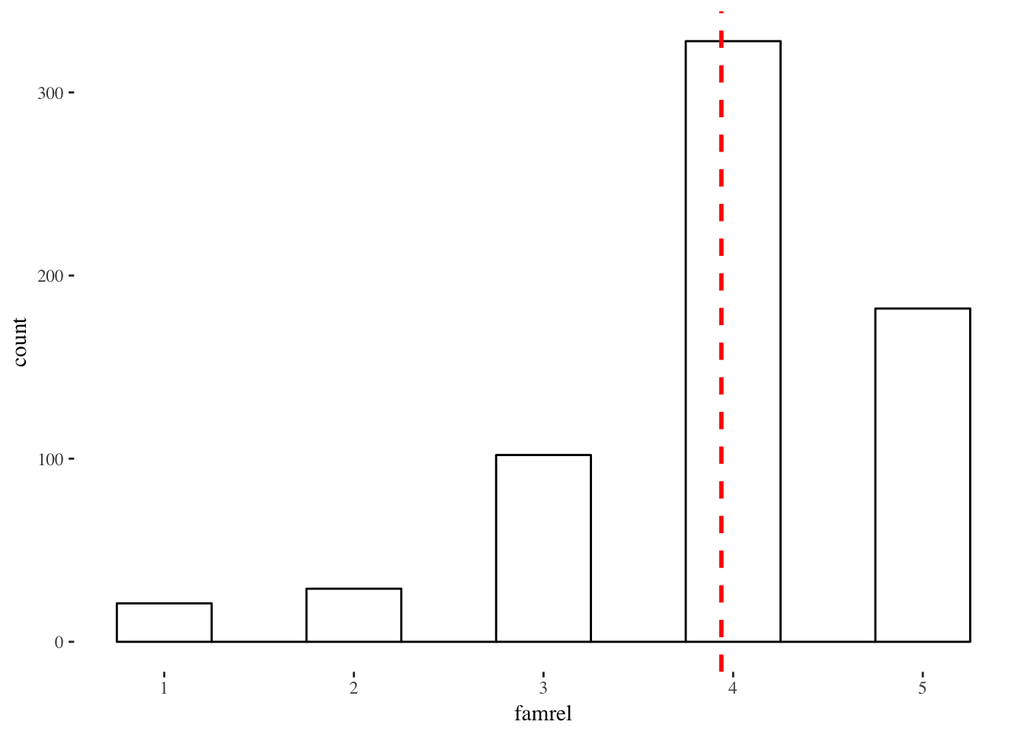

```r
ggplot(d, aes(x=famrel)) +
  geom_histogram(binwidth=.5, colour="black", fill="white") +
  geom_vline(aes(xintercept=mean(famrel, na.rm=T)),   # Ignore NA values for mean
             color="red", linetype="dashed", size=1)
```

### histogram with health on x axis with MEAN

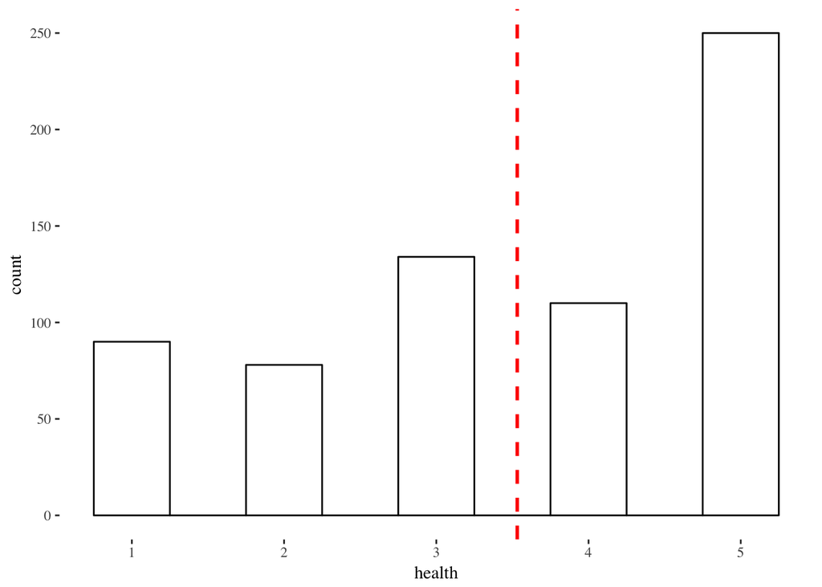

```r
ggplot(d, aes(x=health)) +
  geom_histogram(binwidth=.5, colour="black", fill="white") +
  geom_vline(aes(xintercept=mean(health, na.rm=T)),   # Ignore NA values for mean
             color="red", linetype="dashed", size=1)
```

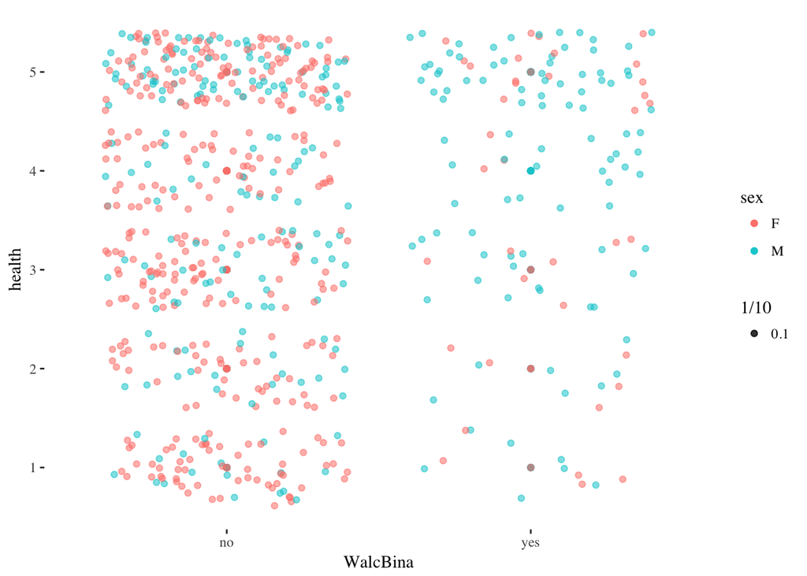

```r
ggplot(d, aes(x=WalcBina, y=health, color=sex, alpha = 1/10)) +
  geom_point() +
  scale_colour_hue(l=70) +
  geom_jitter()
```

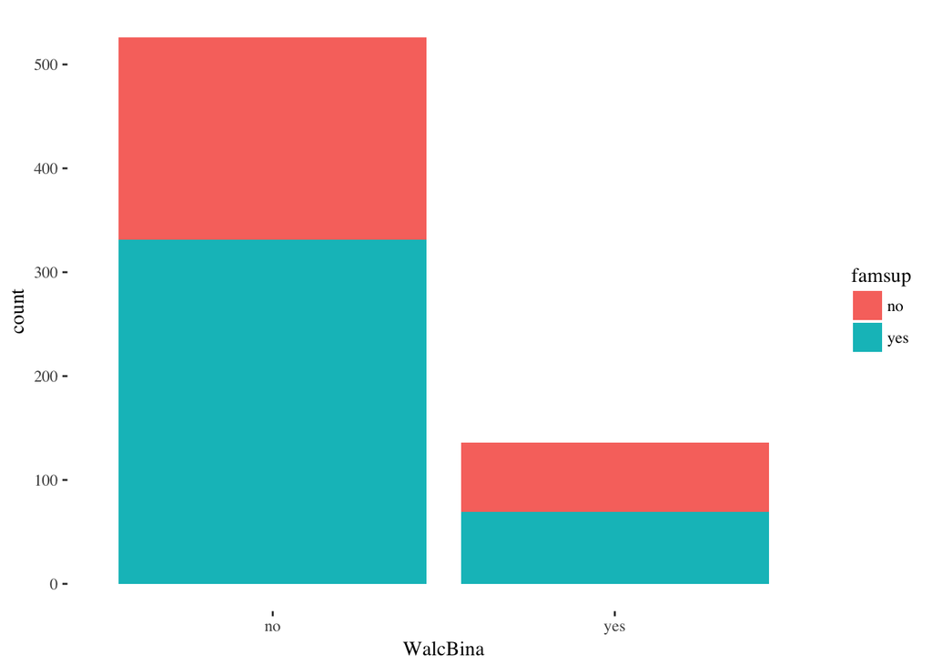

```r
ggplot(d, aes(WalcBina, fill = famsup))+
  geom_bar()
```

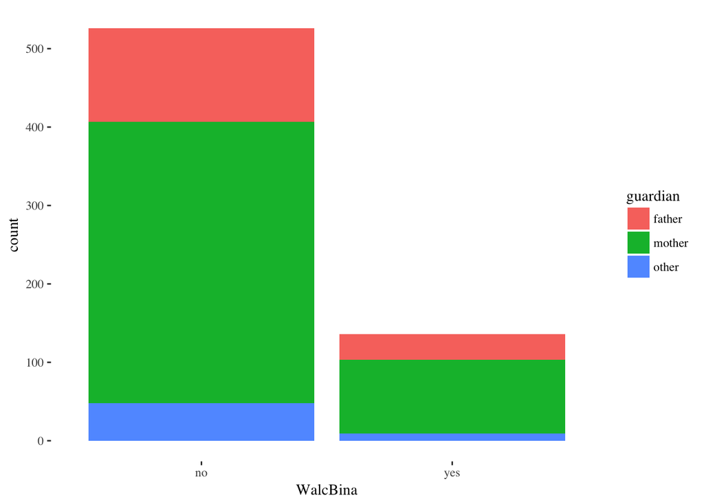

```r
ggplot(d, aes(WalcBina, fill = guardian))+
  geom_bar()
```

## Entrenando el modelo (random forest) y encontrando la prediccion

A continuacion entrenaremos un randomForest a partir del dataset de entrenamiento para posteriormente predecir el nivel de Alc en el dataset de prueba.

```r
randomF <- randomForest(Alc ~ school + sex + age + address + famsize + Pstatus +
                      Medu + Fedu + Mjob + Fjob + reason + nursery + internet, data=train, importance=TRUE, ntree=5000)
```

para ver las variables mas importantes (Entre mayor sea el valor de %IncMSE mas importante es dicha variable)

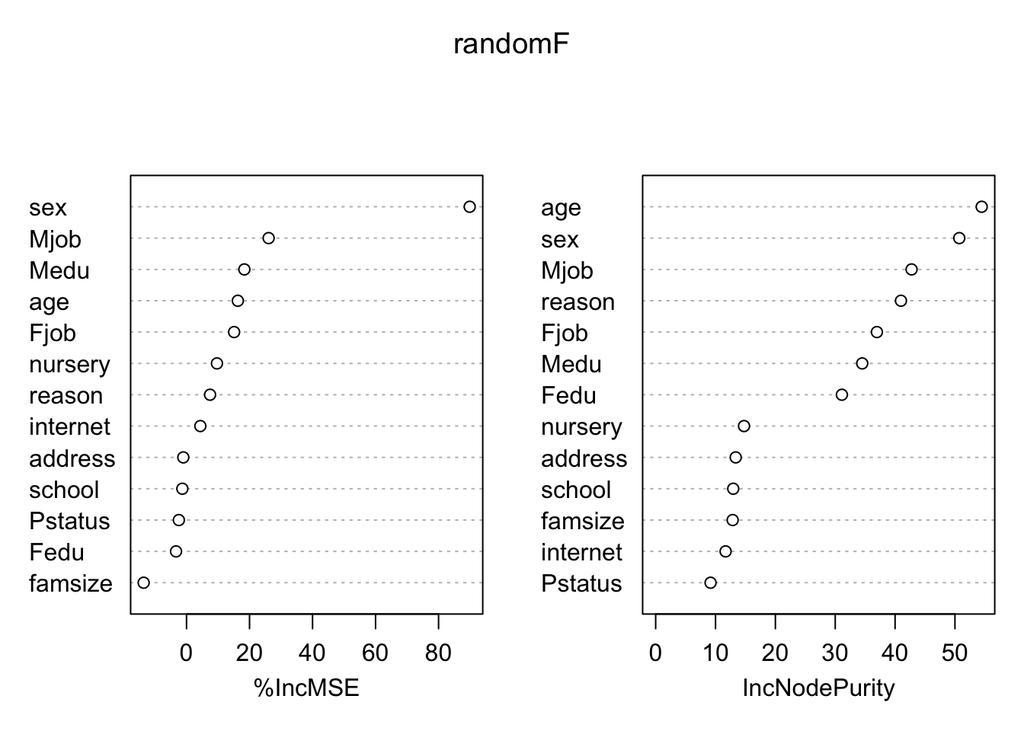

```r
varImpPlot(randomF)
```

Finalmente aqui creamos y llenamos nuestro dataset de prueba para determinar que tanto alcohol toman las personas a partir de sus datos

```r
Prediction <- predict(randomF, test, type = "response")
submit <- data.frame(Survived = Prediction)
```

y ya podemos ver la prediccion:

```r
submit
```

```
##      Survived
## 1    1.481384
## 2    1.395875
## 11   1.668102
## 12   1.673875
## 13   1.884969
## 17   1.709252
## 18   1.411091
## 21   1.487658
## 22   2.305518
## 25   1.366053
## 27   1.393439
## 32   2.025876
## 33   1.623300
## 34   1.806397
```

[output cut: 152 more lines]